# Do citizens of wealthier countries live longer?

# Introduction

The gross domestic product per capita, or GDP per capita, is a measure of a country’s economic output that accounts for its number of people. It divides the country’s gross domestic product by its total population. GDP per capita is an important indicator of economic performance and a useful unit to make cross-country comparisons of average living standards and economic wellbeing.

Life expectancy at birth is defined as how long, on average, a newborn can expect to live, if current death rates do not change. Life expectancy at birth is one of the most frequently used health status indicators.

Large inequalities in life expectancy by countries exist in the world. The big differences in health across the world is clearly visible in the following illustration:

[figure not shown]

*Source:https://ourworldindata.org/life-expectancy*

# Introduction Cont.

**Do citizens of wealthier countries live longer?**

- Do people live longer in countries with a high GDP per capita? Does economic development raise life expectancy?

To answer this, we wanted to investigate the relation between GDP per Capita and the life expectancy of the citizen in the developed countries.

- To have broad coverage, instead of G7 or G20, we focused our investigation on OECD (Organisation for Economic Co-operation and Development) countries which is an association of 37 nations in Europe, North America, and the Pacific. Generally, OECD members are high-income economies with a very high Human Development Index (HDI) and are regarded as developed countries.

# Problem Statement

The question that we want to investigate is:

**“Is there any relationship between a country’s GDP per Capita and Life Expectancy?”**

To answer this, we:

- First, started with descriptive statistics to summarise the characteristics of data and used statistical visualizations to examine important features.
- Second, a correlation analysis is performed to understand the nature of any existing relationship.
- Third, a linear regression model was applied to predict the dependent variable, Life Expectancy, using measures of GDP per capita.
- Finally, reached the conclusion, if the relationship was statistically significant or not.

# Data

A detailed description of datasets considered for data preprocessing, their sources, and variable descriptions are as follows:

#### Dataset Source

- We have collected Life Expectancy data from 2000 to 2019 data from the following source: https://data.oecd.org/healthstat/life-expectancy-at-birth.htm
- And, GDP Per Capita 2000 to 2019 for the OECD countries from the following source: https://data.oecd.org/gdp/gross-domestic-product-gdp.htm

#### The datasets contained:

- ‘LOCATION’: Three-letter country codes defined in ISO, a standardized way to represent a country name.
- ‘INDICATOR’: Indicator information- ‘GDP’ in GDP dataset ‘LIFEEXP’ in Life Expectancy dataset.
- ‘SUBJECT’: ‘TOT’ to indicate the Total level.
- ‘MEASURE’: ‘USD_CAP’ in GDP dataset to indicate that values are in USD per Capita. ‘Y’ Life Expectancy dataset to indicate the values are in Years.
- ‘FREQUENCY’: ‘A’ to indicate Yearly measure
- ‘TIME’: Year of measurement
- ‘Value’: GDP per Capita in USD (GDP dataset) and Life Expectancy in Years (Life Expectancy dataset)
- ‘Flag Codes’: Contains code for countries

# Data Cont.

- To select only the variables that we would need for the analysis, we considered only ‘LOCATION’, ‘TIME’, and ‘Value’ in each dataset.
- Renamed the ’TIME’ column of both the data sets to ‘YEAR’ and renamed the “VALUE’ to more intuitive names ‘GDP’ and ‘LIFEEXP’ in the respective datasets.
- Initial inspection revealed that the majority country did not have Life Expectancy data for the year 2019, so only considered the 2000 to 2018 period for both the datasets.
- Both the datasets were in a tidy format, so we merged both the datasets named it as ‘gdp_lifeexp_data’.
- ‘GDP’ and ‘LIFEEXP’ were in numeric class and this was suitable for the analysis.
- Data scanning revealed that there were 3 missing values in the Life Expectancy variable. Upon investigating further, we had decided to omit the records with missing values from the analysis instead of recoding these missing values with the mean values.
- Post data-preprocessing, the final dataset contained 700 observations. We have uploaded the data final pre-processed data to the Kaggle site for easy reference: https://www.kaggle.com/rajibrd/gdp-and-life-expectancy-of-oecd-countries

```r
newdata <- read_excel("gdp_lifeexp_data.xlsx")
head(newdata)
```

```
## # A tibble: 6 x 4
##   LOCATION  YEAR    GDP LIFEEXP
##   <chr>    <dbl>  <dbl>   <dbl>
## 1 AUS       2000 28249.    79.3
## 2 AUS       2001 29475.    79.7
## 3 AUS       2002 30741.    80
## 4 AUS       2003 32245.    80.3
## 5 AUS       2004 33857.    80.6
## 6 AUS       2005 35571.    80.9
```

# Descriptive Statistics

- GDP per Capita ranges from USD 6777 to USD 116622.
- Life Expectancy varies from 70.1 to 84.2 years old.

```r
summary1 <- newdata %>% summarise(Min = min(GDP,na.rm = TRUE), Q1 = quantile(GDP,probs = .25,na.rm = TRUE),
                       Median = median(GDP, na.rm = TRUE), Q3 = quantile(GDP,probs = .75,na.rm = TRUE),
                       Max = max(GDP,na.rm = TRUE), Mean = mean(GDP, na.rm = TRUE),
                       SD = sd(GDP, na.rm = TRUE), n = n(),
                       Missing = sum(is.na(GDP)))
knitr::kable(summary1,caption="Summary Statistics for GDP per Capita")
```

Summary Statistics for GDP per Capita

| Min | Q1 | Median | Q3 | Max | Mean | SD | n | Missing |
| --- | --- | --- | --- | --- | --- | --- | --- | --- |
| 6776.995 | 23859.79 | 31877.07 | 41360.25 | 116622.2 | 33850.01 | 15703.31 | 700 | 0 |

```r
summary2 <- newdata %>% summarise(Min = min(LIFEEXP,na.rm = TRUE), Q1 = quantile(LIFEEXP,probs = .25,na.rm = TRUE),
                                  Median = median(LIFEEXP, na.rm = TRUE), Q3 = quantile(LIFEEXP,probs = .75,na.rm = TRUE),
                                  Max = max(LIFEEXP,na.rm = TRUE), Mean = mean(LIFEEXP, na.rm = TRUE),
                                  SD = sd(LIFEEXP, na.rm = TRUE), n = n(),
                                  Missing = sum(is.na(LIFEEXP)))
knitr::kable(summary2,caption="Summary Statistics for Life Expentancy")
```

Summary Statistics for Life Expentancy

| Min | Q1 | Median | Q3 | Max | Mean | SD | n | Missing |
| --- | --- | --- | --- | --- | --- | --- | --- | --- |
| 70.1 | 77.1 | 79.7 | 81.4 | 84.2 | 78.95329 | 3.092587 | 700 | 0 |

# Visualisation

- From the histogram, there seems to be a couple of observations higher than all other observations in GDP and some observations are lower in LIFEEXP (Life Expectancy).
- The GDP per capita histogram is slightly right-skewed and the life expectancy is slightly left-skewed.
- The GDP histogram shows many outliers.

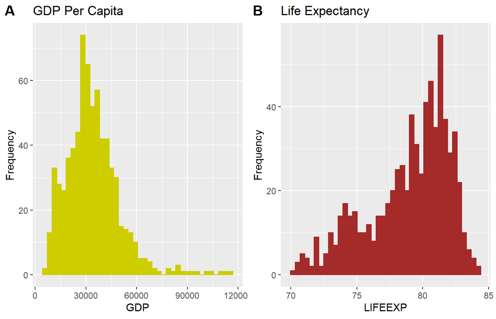

```r
g1 <- ggplot(newdata,aes(GDP))+geom_histogram(bins=40,color = "yellow3", fill="yellow3")+ ylab('Frequency')+ggtitle('GDP Per Capita')
g2 <- ggplot(newdata,aes(LIFEEXP))+geom_histogram(bins=40,color = "brown", fill="brown")+ ylab('Frequency')+ggtitle('Life Expectancy')
cowplot::plot_grid(g1, g2, labels = "AUTO")
```

# Visualisation 2

- Plotted Boxplot to understand the data and identified the values of the potential outliers based on the IQR criterion.
- Further investigation (not shown here as it was part of data pre-processing) using a bivariate box plot revealed that there were no obvious outliers or abnormal observations when we included the respective country into consideration. Hence, there was no justifiable reason to remove these outliers. These outliers values are legitimate observations and we should leave it in the dataset. It would not be appropriate practice to remove valid data points simply to produce a better fitting model or statistically significant results.

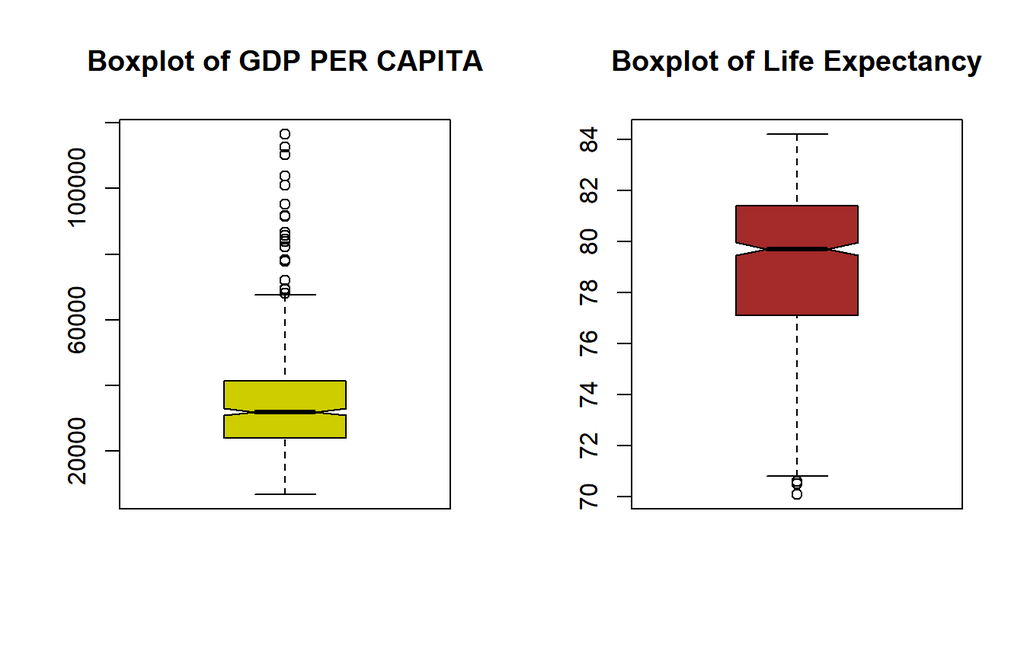

```
##  [1]  69147  72018  78211  84575  68141  77891  83852  86592  82269  85579
## [11]  91814  91527  95246 100934 103788 110250 112702 116622  69358
```

```
## [1] 70.1 70.5 70.6 70.6
```

```r
par(mfrow = c(1,2))
boxplot(newdata$GDP, main="Boxplot of GDP PER CAPITA",col='yellow3', notch = T)
boxplot(newdata$LIFEEXP, main="Boxplot of Life Expectancy", col='brown', notch = T)
```

# Visualisation 3

- From the scatter plot, we can see that the data exhibit signs of a positive linear relationship

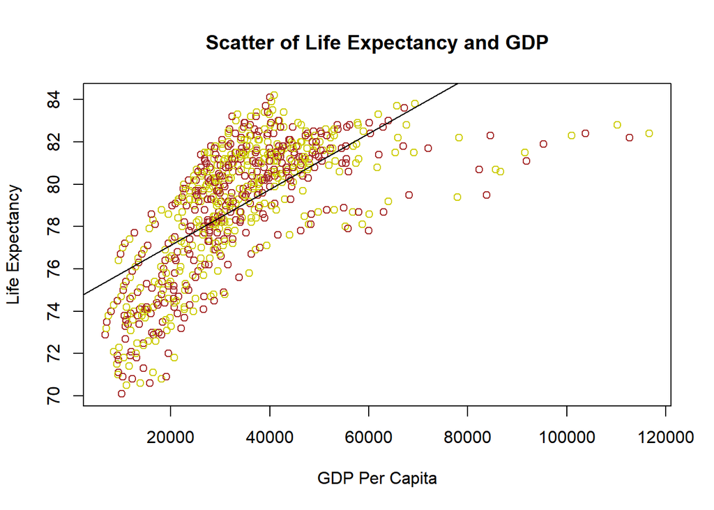

```r
plot(LIFEEXP ~ GDP, data = newdata, main="Scatter of Life Expectancy and GDP",
        ylab="Life Expectancy", xlab="GDP Per Capita", col=c('brown', 'yellow3'))
abline(lm(LIFEEXP ~ GDP, data = newdata))
```

# Hypothesis Testing 1

**Correlation Analysis**

**Hypothesis Generation**

Ho : There is no correlation between GDP per Capita of an OECD country and its Life Expectancy.

Ha : There is significant correlation between GDP per Capita of an OECD country and its Life Expectancy.

Mathematically,

Ho :r = 0

Ha : r ≠ 0

# Test Result 1

A Pearson’s correlation was calculated to measure the strength of the linear relationship between GDP per capita of a OECD country and its life expectancy. The positive correlation was statistically significant, r=.67, p<.001, 95% CI [0.628, .710].

We can say that there are statistically significant evidence to reject Ho.

```r
#Creating a correlation matrix
corr<-as.matrix(dplyr::select(newdata, LIFEEXP, GDP))
rcorr(corr, type = "pearson")
```

```
##         LIFEEXP  GDP
## LIFEEXP    1.00 0.67
## GDP        0.67 1.00
##
## n= 700
##
##
## P
##         LIFEEXP GDP
## LIFEEXP          0
## GDP      0
```

```r
r=cor(newdata$LIFEEXP,newdata$GDP)
CIr(r = r, n = 700, level = .95) %>% round(3)
```

```
## [1] 0.628 0.710
```

# Hypthesis Testing 2

**Linear Regression Model**

**Hypothesis Generation**

Ho: The data do not fit the linear regression model

Ha: The data fit the linear regression model

Mathematically,

Ho : α = 0

Ha : α ≠ 0

# Test Result 2

- As p<.001. So there was statistically significant evidence that per capita GDP was positively related to life expectancy. Therefore, we reject Ho.
- Country’s GDP per capita measure explained 45.02% of the variability in country’s life expectancy.

```r
gdplifeexpmodel <- lm(LIFEEXP ~ GDP, data = newdata) # fitting the linear regression model using the lm() function
gdplifeexpmodel %>% summary()
```

```
##
## Call:
## lm(formula = LIFEEXP ~ GDP, data = newdata)
##
## Residuals:
##     Min      1Q  Median      3Q     Max
## -7.4908 -1.4302  0.3848  1.6505  4.4314
##
## Coefficients:
##              Estimate Std. Error t value Pr(>|t|)
## (Intercept) 7.448e+01  2.062e-01  361.17   <2e-16 ***
## GDP         1.321e-04  5.527e-06   23.91   <2e-16 ***
## ---
## Signif. codes:  0 '***' 0.001 '**' 0.01 '*' 0.05 '.' 0.1 ' ' 1
##
## Residual standard error: 2.295 on 698 degrees of freedom
## Multiple R-squared:  0.4502, Adjusted R-squared:  0.4494
## F-statistic: 571.6 on 1 and 698 DF,  p-value: < 2.2e-16
```

```r
gdplifeexpmodel %>% confint() # calculating 95% CI
```

```
##                    2.5 %       97.5 %
## (Intercept) 7.407545e+01 7.488522e+01
## GDP         1.212884e-04 1.429922e-04
```

# Assumptions validation for linear regression

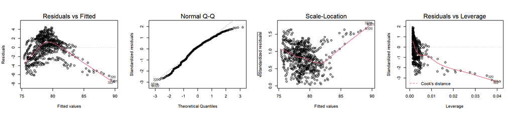

```r
par(mfrow=c(1,4))
plot(gdplifeexpmodel)
```

# Discussion

# Discussion Cont.

- All countries make efforts to improve the health of their citizens, not with the same success though, resulting in large inequalities in life expectancy across countries.
- This study can provide valuable insights to policymakers, particular in the area of income, resource allocation, and health and population policies/programs.
- We can extend this study further and delve into the relationship between Life Expectancy and Healthcare spending per capita to examine other determinants of health care expenditure.
- Further evaluation can be conducted to reduce the skewness in the distribution, taking roots or logarithms or reciprocals transformation to address right skewness and taking squares or cubes or higher powers to reduce left skewness. Box-Cox Transformation can also be useful in our case of linear regression analysis.

# References

- Statistics by Jim. c2020. Jim Frost. Consulted 11/10/20. Retrieved from:‘https://statisticsbyjim.com/basics/remove-outliers/’
- Applied Analytics Course website. c2016. James Baglin. Module 9. Simple Linear Regression and Correlation. Updated 13/07/20. Consulted 11/10/20. Retrieved from:‘https://astral-theory-157510.appspot.com/secured/MATH1324_Module_09.html’
- Our World in Data. Global Change Data Lab. Max Roser, Esteban Ortiz-Ospina and Hannah Ritchie (2013) - “Life Expectancy”. Published online at OurWorldInData.org. Retrieved from: ‘https://ourworldindata.org/life-expectancy’ [Online Resource]
- Euromonitor International. c2020. Retrieved from: ‘https://blog.euromonitor.com/economic-growth-and-life-expectancy-do-wealthier-countries-live-longer/’